# Wizualizacja danych I

## Domyślne ustawienia narzędzi

Przykład problemu: domyślne ustawienia etykiet na osi X utrudnia ich odczytanie.

## Domyślne ustawienia narzędzi

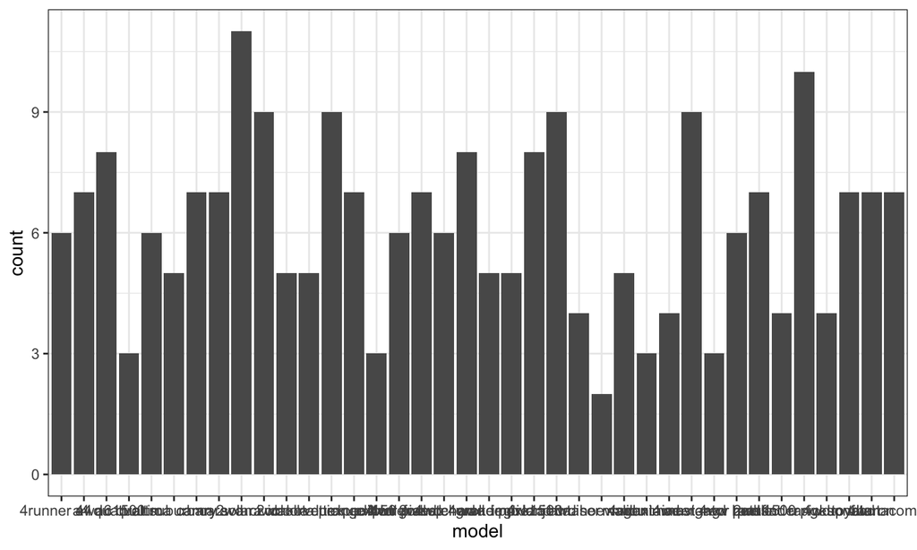

```r
ggplot(mpg, aes(x = model)) +
  geom_bar()
```

## Domyślne ustawienia narzędzi

Rozwiązanie problemu: zmiana ustawienia etykiet na osi X.

## Domyślne ustawienia narzędzi

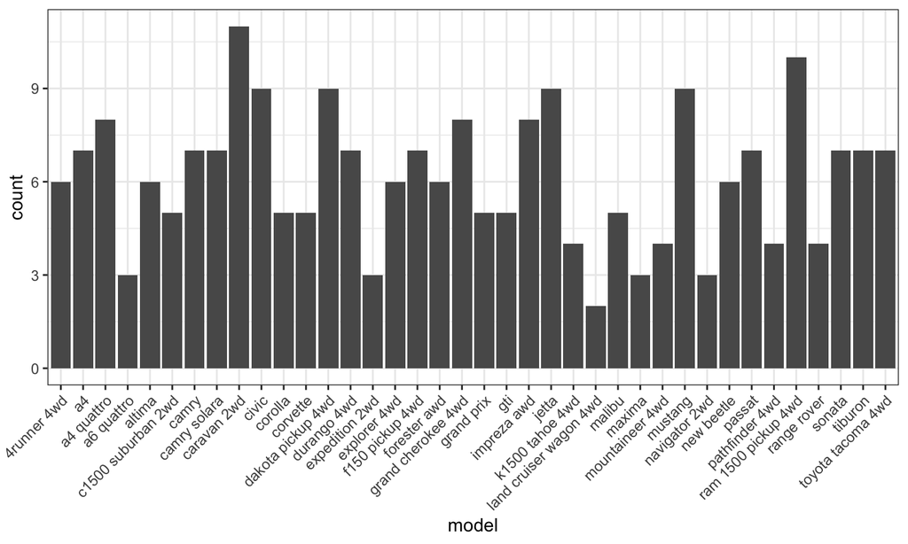

```r
ggplot(mpg, aes(x = model)) +
  geom_bar() +
  theme(axis.text.x = element_text(angle = 45, hjust = 1))
```

## Domyślne ustawienia narzędzi

Dobrze dobrane domyślne ustawienia znacząco przyśpieszają naszą pracę i pozwalają przenieść część decyzji na autorów narzędzia.

Są one **szczególnie** istotne przy budowaniu dashboardów lub automatycznych raportów, gdzie wizualizacje są budowane na zmieniających się zbiorach danych.

## Koszt wejścia w narzędzie

Koszt wejścia w narzędzie to czas i wysiłek potrzebny do nauczenia się jego używania. Koszt ten jest różny dla różnych narzędzi i zależy od ich złożoności oraz dostępności dokumentacji.

Narzędzia o niskim koszcie wejścia: MS Excel, Datawrapper.

Narzędzia o wysokim koszcie wejścia: ggplot2, Seaborn, matplotlib.

## Jak wybrać narzędzie pod względem kosztu?

Aby prawidłowo wybrać narzędzie o jak najmniejszym koszcie wejścia, potrzebne jest **doświadczenie**, aby oszacować ukryte koszty.

Narzędzia o niskim koszcie wejścia często szybko „blokują” użytkownika, gdy chce on wykroczyć poza podstawowe funkcje. Duża część domyślnych parametrów lub sposobów działania może być głęboko zaszyta w narzędziu co utrudnia ich modyfikację.

## Koszt wejścia w narzędzie

Koszt wejścia w narzędzie to inwestycja.

Krótki czas do uzyskania pierwszego wykresu nie zawsze oznacza uzyskanie oczekiwanych efektów (np. skalowalności, automatyzacji).

## SI a wizualizacja danych

Wykorzystanie sztucznej inteligencji w wizualizacji danych:

1. Narzędzia oparte o SI do generowania wykresów.
2. Generowanie kodu za pomocą SI tworzącego wykresy.

## Narzędzia oparte o SI

- Quadratic AI
- Julius AI
- Data Formulator
- Rose.ai
- ChartGPT
- [lida](https://microsoft.github.io/lida/).

Problemy: bezpieczeństwo danych, jakość generowanych wykresów, brak kontroli nad wizualizacją.

## Generowanie kodu za pomocą SI

Problemy:

- nieaktualność kodu (frameworki do wizualizacji danych ewoluują bardzo szybko),
- niska jakość powstałych wizualizacji jeśli są bardziej zaawansowane,
- arbitralność podjętych decyzji bez zrozumienia celu analizy.

## Generowanie kodu za pomocą SI

Problemy:

- nieaktualność kodu (frameworki do wizualizacji danych ewoluują bardzo szybko),
- niska jakość powstałych wizualizacji jeśli są bardziej zaawansowane,
- arbitralność podjętych decyzji bez zrozumienia celu analizy.

## Generowanie kodu za pomocą SI

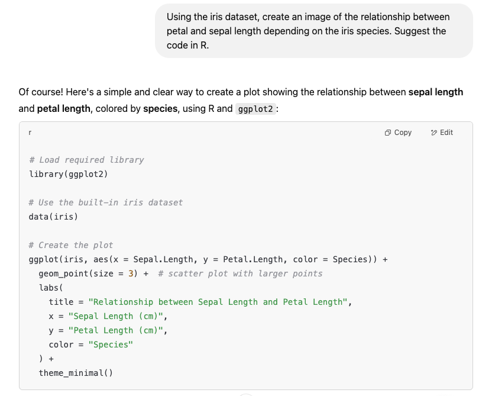

## Generowanie kodu za pomocą SI

W przypadku wątpliwości - sprawdźmy, czy narzędzie było testowane na zbiorze [NVbench](https://sites.google.com/view/nvbench/).

## Praca w grupach

1. Każda osoba w grupie samodzielnie zapisuje 2–3 cechy, które według niej są najważniejsze w narzędziu do wizualizacji.
2. Dyskusja w grupie:
   1. Które cechy podane przez członków grupy są zbieżne ze sobą, a które są różne od siebie?
   2. Dlaczego te różnice się pojawiły? Czy wynikają z innych doświadczeń lub z innych potrzeb dotyczących wizualizacji danych?
3. Pisemne podsumowanie:
   1. Jedna cecha, która jest istotna dla wszystkich członków grupy.
   2. Najbardziej zaskakująca różnica oczekiwań i krótko wyjaśnienie, dlaczego ta różnica się pojawiła.

## Najlepsze narzędzie do wizualizacji

Wybór narzędzia do wizualizacji to nie kwestia technologii, ale umiejętności twórcy, celu komunikacyjnego i kontekstu.

## Kontakt

Materiały: https://github.com/michbur/WizualizacjaDanych2025-2026L

Mail: michalburdukiewicz@gmail.com